# Cluster Analysis on Breakfast Cereal

## Problem Description

- In the following Unsupervised Learning activity, we try to cluster various types of breakfast cereal based on their nutritional content.

```r
setwd("~/R_KSU/ML/Assignment5")
cereals_data <- read.csv("Cereals.csv", header=T)
data <- cereals_data
str(cereals_data)
```

```
## 'data.frame':    77 obs. of  16 variables:
##  $ name    : chr  "100%_Bran" "100%_Natural_Bran" "All-Bran" "All-Bran_with_Extra_Fiber" ...
##  $ mfr     : chr  "N" "Q" "K" "K" ...
##  $ type    : chr  "C" "C" "C" "C" ...
##  $ calories: int  70 120 70 50 110 110 110 130 90 90 ...
##  $ protein : int  4 3 4 4 2 2 2 3 2 3 ...
##  $ fat     : int  1 5 1 0 2 2 0 2 1 0 ...
##  $ sodium  : int  130 15 260 140 200 180 125 210 200 210 ...
##  $ fiber   : num  10 2 9 14 1 1.5 1 2 4 5 ...
##  $ carbo   : num  5 8 7 8 14 10.5 11 18 15 13 ...
##  $ sugars  : int  6 8 5 0 8 10 14 8 6 5 ...
##  $ potass  : int  280 135 320 330 NA 70 30 100 125 190 ...
##  $ vitamins: int  25 0 25 25 25 25 25 25 25 25 ...
##  $ shelf   : int  3 3 3 3 3 1 2 3 1 3 ...
##  $ weight  : num  1 1 1 1 1 1 1 1.33 1 1 ...
##  $ cups    : num  0.33 1 0.33 0.5 0.75 0.75 1 0.75 0.67 0.67 ...
##  $ rating  : num  68.4 34 59.4 93.7 34.4 ...
```

```r
summary(cereals_data)
```

```
##      name               mfr                type              calories
##  Length:77          Length:77          Length:77          Min.   : 50.0
##  Class :character   Class :character   Class :character   1st Qu.:100.0
##  Mode  :character   Mode  :character   Mode  :character   Median :110.0
##                                                           Mean   :106.9
##                                                           3rd Qu.:110.0
##                                                           Max.   :160.0
##
##     protein           fat            sodium          fiber
##  Min.   :1.000   Min.   :0.000   Min.   :  0.0   Min.   : 0.000
##  1st Qu.:2.000   1st Qu.:0.000   1st Qu.:130.0   1st Qu.: 1.000
##  Median :3.000   Median :1.000   Median :180.0   Median : 2.000
##  Mean   :2.545   Mean   :1.013   Mean   :159.7   Mean   : 2.152
##  3rd Qu.:3.000   3rd Qu.:2.000   3rd Qu.:210.0   3rd Qu.: 3.000
##  Max.   :6.000   Max.   :5.000   Max.   :320.0   Max.   :14.000
##
##      carbo          sugars           potass          vitamins
##  Min.   : 5.0   Min.   : 0.000   Min.   : 15.00   Min.   :  0.00
##  1st Qu.:12.0   1st Qu.: 3.000   1st Qu.: 42.50   1st Qu.: 25.00
##  Median :14.5   Median : 7.000   Median : 90.00   Median : 25.00
##  Mean   :14.8   Mean   : 7.026   Mean   : 98.67   Mean   : 28.25
##  3rd Qu.:17.0   3rd Qu.:11.000   3rd Qu.:120.00   3rd Qu.: 25.00
##  Max.   :23.0   Max.   :15.000   Max.   :330.00   Max.   :100.00
##  NA's   :1      NA's   :1        NA's   :2
##      shelf           weight          cups           rating
##  Min.   :1.000   Min.   :0.50   Min.   :0.250   Min.   :18.04
##  1st Qu.:1.000   1st Qu.:1.00   1st Qu.:0.670   1st Qu.:33.17
##  Median :2.000   Median :1.00   Median :0.750   Median :40.40
##  Mean   :2.208   Mean   :1.03   Mean   :0.821   Mean   :42.67
##  3rd Qu.:3.000   3rd Qu.:1.00   3rd Qu.:1.000   3rd Qu.:50.83
##  Max.   :3.000   Max.   :1.50   Max.   :1.500   Max.   :93.70
##
```

```r
head(cereals_data)
```

|  | name | mfr | type | calories | protein | fat | sodium | fiber | carbo | sugars | potass | vitamins | shelf | weight | cups | rating |
| --- | --- | --- | --- | --- | --- | --- | --- | --- | --- | --- | --- | --- | --- | --- | --- | --- |
| 1 | 100%_Bran | N | C | 70 | 4 | 1 | 130 | 10.0 | 5.0 | 6 | 280 | 25 | 3 | 1 | 0.33 | 68.40297 |
| 2 | 100%_Natural_Bran | Q | C | 120 | 3 | 5 | 15 | 2.0 | 8.0 | 8 | 135 | 0 | 3 | 1 | 1.00 | 33.98368 |
| 3 | All-Bran | K | C | 70 | 4 | 1 | 260 | 9.0 | 7.0 | 5 | 320 | 25 | 3 | 1 | 0.33 | 59.42551 |
| 4 | All-Bran_with_Extra_Fiber | K | C | 50 | 4 | 0 | 140 | 14.0 | 8.0 | 0 | 330 | 25 | 3 | 1 | 0.50 | 93.70491 |
| 5 | Almond_Delight | R | C | 110 | 2 | 2 | 200 | 1.0 | 14.0 | 8 | NA | 25 | 3 | 1 | 0.75 | 34.38484 |
| 6 | Apple_Cinnamon_Cheerios | G | C | 110 | 2 | 2 | 180 | 1.5 | 10.5 | 10 | 70 | 25 | 1 | 1 | 0.75 | 29.50954 |

```r
tail(cereals_data)
```

|  | name | mfr | type | calories | protein | fat | sodium | fiber | carbo | sugars | potass | vitamins | shelf | weight | cups | rating |
| --- | --- | --- | --- | --- | --- | --- | --- | --- | --- | --- | --- | --- | --- | --- | --- | --- |
| 72 | Total_Whole_Grain | G | C | 100 | 3 | 1 | 200 | 3 | 16 | 3 | 110 | 100 | 3 | 1 | 1.00 | 46.65884 |
| 73 | Triples | G | C | 110 | 2 | 1 | 250 | 0 | 21 | 3 | 60 | 25 | 3 | 1 | 0.75 | 39.10617 |
| 74 | Trix | G | C | 110 | 1 | 1 | 140 | 0 | 13 | 12 | 25 | 25 | 2 | 1 | 1.00 | 27.75330 |
| 75 | Wheat_Chex | R | C | 100 | 3 | 1 | 230 | 3 | 17 | 3 | 115 | 25 | 1 | 1 | 0.67 | 49.78744 |
| 76 | Wheaties | G | C | 100 | 3 | 1 | 200 | 3 | 17 | 3 | 110 | 25 | 1 | 1 | 1.00 | 51.59219 |
| 77 | Wheaties_Honey_Gold | G | C | 110 | 2 | 1 | 200 | 1 | 16 | 8 | 60 | 25 | 1 | 1 | 0.75 | 36.18756 |

# Data Pre-Processing

```r
# Total number of NA values in the data set
colSums(is.na(cereals_data))
```

```
##     name      mfr     type calories  protein      fat   sodium    fiber
##        0        0        0        0        0        0        0        0
##    carbo   sugars   potass vitamins    shelf   weight     cups   rating
##        1        1        2        0        0        0        0        0
```

```r
# comment: There are 4 NA values in dataset we shall remove those.
cereals_data <- na.omit(cereals_data)

#check for NA values again
colSums(is.na(cereals_data))
```

```
##     name      mfr     type calories  protein      fat   sodium    fiber
##        0        0        0        0        0        0        0        0
##    carbo   sugars   potass vitamins    shelf   weight     cups   rating
##        0        0        0        0        0        0        0        0
```

```r
# Setting the rownames of the breakfast cereals to the row names, as this will later help us in visualizing the clusters.
data <- cereals_data
rownames(cereals_data) <- cereals_data$name
cereals_data$name = NULL
head(cereals_data)
```

|  | mfr | type | calories | protein | fat | sodium | fiber | carbo | sugars | potass | vitamins | shelf | weight | cups | rating |
| --- | --- | --- | --- | --- | --- | --- | --- | --- | --- | --- | --- | --- | --- | --- | --- |
| 100%_Bran | N | C | 70 | 4 | 1 | 130 | 10.0 | 5.0 | 6 | 280 | 25 | 3 | 1 | 0.33 | 68.40297 |
| 100%_Natural_Bran | Q | C | 120 | 3 | 5 | 15 | 2.0 | 8.0 | 8 | 135 | 0 | 3 | 1 | 1.00 | 33.98368 |
| All-Bran | K | C | 70 | 4 | 1 | 260 | 9.0 | 7.0 | 5 | 320 | 25 | 3 | 1 | 0.33 | 59.42551 |
| All-Bran_with_Extra_Fiber | K | C | 50 | 4 | 0 | 140 | 14.0 | 8.0 | 0 | 330 | 25 | 3 | 1 | 0.50 | 93.70491 |
| Apple_Cinnamon_Cheerios | G | C | 110 | 2 | 2 | 180 | 1.5 | 10.5 | 10 | 70 | 25 | 1 | 1 | 0.75 | 29.50954 |
| Apple_Jacks | K | C | 110 | 2 | 0 | 125 | 1.0 | 11.0 | 14 | 30 | 25 | 2 | 1 | 1.00 | 33.17409 |

```r
## Converting categorical variables into dummy variables
library(fastDummies)
cereals_data <- fastDummies::dummy_cols(cereals_data, select_columns = "mfr")[,-1]
cereals_data <- fastDummies::dummy_cols(cereals_data, select_columns = "type")[,-1]
cereals_data <- fastDummies::dummy_cols(cereals_data, select_columns = "shelf")[,-10]
str(cereals_data)
```

```
## 'data.frame':    74 obs. of  24 variables:
##  $ calories: int  70 120 70 50 110 110 130 90 90 120 ...
##  $ protein : int  4 3 4 4 2 2 3 2 3 1 ...
##  $ fat     : int  1 5 1 0 2 0 2 1 0 2 ...
##  $ sodium  : int  130 15 260 140 180 125 210 200 210 220 ...
##  $ fiber   : num  10 2 9 14 1.5 1 2 4 5 0 ...
##  $ carbo   : num  5 8 7 8 10.5 11 18 15 13 12 ...
##  $ sugars  : int  6 8 5 0 10 14 8 6 5 12 ...
##  $ potass  : int  280 135 320 330 70 30 100 125 190 35 ...
##  $ vitamins: int  25 0 25 25 25 25 25 25 25 25 ...
##  $ weight  : num  1 1 1 1 1 1 1.33 1 1 1 ...
##  $ cups    : num  0.33 1 0.33 0.5 0.75 1 0.75 0.67 0.67 0.75 ...
##  $ rating  : num  68.4 34 59.4 93.7 29.5 ...
##  $ mfr_A   : int  0 0 0 0 0 0 0 0 0 0 ...
##  $ mfr_G   : int  0 0 0 0 1 0 1 0 0 0 ...
##  $ mfr_K   : int  0 0 1 1 0 1 0 0 0 0 ...
##  $ mfr_N   : int  1 0 0 0 0 0 0 0 0 0 ...
##  $ mfr_P   : int  0 0 0 0 0 0 0 0 1 0 ...
##  $ mfr_Q   : int  0 1 0 0 0 0 0 0 0 1 ...
##  $ mfr_R   : int  0 0 0 0 0 0 0 1 0 0 ...
##  $ type_C  : int  1 1 1 1 1 1 1 1 1 1 ...
##  $ type_H  : int  0 0 0 0 0 0 0 0 0 0 ...
##  $ shelf_1 : int  0 0 0 0 1 0 0 1 0 0 ...
##  $ shelf_2 : int  0 0 0 0 0 1 0 0 0 1 ...
##  $ shelf_3 : int  1 1 1 1 0 0 1 0 1 0 ...
```

```r
# Assigning cereal lables as row names of the data frame.
rownames(cereals_data) <- data$name
head(cereals_data)
```

|  | calories | protein | fat | sodium | fiber | carbo | sugars | potass | vitamins | weight | cups | rating | mfr_A | mfr_G | mfr_K | mfr_N | mfr_P | mfr_Q | mfr_R | type_C | type_H | shelf_1 | shelf_2 | shelf_3 |
| --- | --- | --- | --- | --- | --- | --- | --- | --- | --- | --- | --- | --- | --- | --- | --- | --- | --- | --- | --- | --- | --- | --- | --- | --- |
| 100%_Bran | 70 | 4 | 1 | 130 | 10.0 | 5.0 | 6 | 280 | 25 | 1 | 0.33 | 68.40297 | 0 | 0 | 0 | 1 | 0 | 0 | 0 | 1 | 0 | 0 | 0 | 1 |
| 100%_Natural_Bran | 120 | 3 | 5 | 15 | 2.0 | 8.0 | 8 | 135 | 0 | 1 | 1.00 | 33.98368 | 0 | 0 | 0 | 0 | 0 | 1 | 0 | 1 | 0 | 0 | 0 | 1 |
| All-Bran | 70 | 4 | 1 | 260 | 9.0 | 7.0 | 5 | 320 | 25 | 1 | 0.33 | 59.42551 | 0 | 0 | 1 | 0 | 0 | 0 | 0 | 1 | 0 | 0 | 0 | 1 |
| All-Bran_with_Extra_Fiber | 50 | 4 | 0 | 140 | 14.0 | 8.0 | 0 | 330 | 25 | 1 | 0.50 | 93.70491 | 0 | 0 | 1 | 0 | 0 | 0 | 0 | 1 | 0 | 0 | 0 | 1 |
| Apple_Cinnamon_Cheerios | 110 | 2 | 2 | 180 | 1.5 | 10.5 | 10 | 70 | 25 | 1 | 0.75 | 29.50954 | 0 | 1 | 0 | 0 | 0 | 0 | 0 | 1 | 0 | 1 | 0 | 0 |
| Apple_Jacks | 110 | 2 | 0 | 125 | 1.0 | 11.0 | 14 | 30 | 25 | 1 | 1.00 | 33.17409 | 0 | 0 | 1 | 0 | 0 | 0 | 0 | 1 | 0 | 0 | 1 | 0 |

## Data Normalization

```r
## Data Scaling
mean_norm_minmax <- function(x){
                                (x- mean(x)) /(max(x)-min(x))
}

cereals_data <- as.data.frame(lapply(cereals_data, mean_norm_minmax))
rownames(cereals_data) <- data$name
#cereals_data_norm <- scale(cereals_data_dum, center = T, scale = T)
head(cereals_data)
```

|  | calories | protein | fat | sodium | fiber | carbo | sugars | potass | vitamins | weight | cups | rating | mfr_A | mfr_G | mfr_K | mfr_N | mfr_P | mfr_Q | mfr_R | type_C | type_H | shelf_1 | shelf_2 | shelf_3 |
| --- | --- | --- | --- | --- | --- | --- | --- | --- | --- | --- | --- | --- | --- | --- | --- | --- | --- | --- | --- | --- | --- | --- | --- | --- |
| 100%_Bran | -0.33660934 | 0.2972973 | 0.0 | -0.1011402 | 0.55888031 | -0.5405405 | -0.07387387 | 0.57614758 | -0.04054054 | -0.03081081 | -0.3932973 | 0.3440454 | -0.01351351 | -0.2972973 | -0.3108108 | 0.93243243 | -0.1216216 | -0.09459459 | -0.09459459 | 0.01351351 | -0.01351351 | -0.2567568 | -0.2702703 | 0.527027 |
| 100%_Natural_Bran | 0.11793612 | 0.0972973 | 0.8 | -0.4605152 | -0.01254826 | -0.3738739 | 0.05945946 | 0.11583012 | -0.29054054 | -0.03081081 | 0.1427027 | -0.1108628 | -0.01351351 | -0.2972973 | -0.3108108 | -0.06756757 | -0.1216216 | 0.90540541 | -0.09459459 | 0.01351351 | -0.01351351 | -0.2567568 | -0.2702703 | 0.527027 |
| All-Bran | -0.33660934 | 0.2972973 | 0.0 | 0.3051098 | 0.48745174 | -0.4294294 | -0.14054054 | 0.70313170 | -0.04054054 | -0.03081081 | -0.3932973 | 0.2253933 | -0.01351351 | -0.2972973 | 0.6891892 | -0.06756757 | -0.1216216 | -0.09459459 | -0.09459459 | 0.01351351 | -0.01351351 | -0.2567568 | -0.2702703 | 0.527027 |
| All-Bran_with_Extra_Fiber | -0.51842752 | 0.2972973 | -0.2 | -0.0698902 | 0.84459459 | -0.3738739 | -0.47387387 | 0.73487773 | -0.04054054 | -0.03081081 | -0.2572973 | 0.6784526 | -0.01351351 | -0.2972973 | 0.6891892 | -0.06756757 | -0.1216216 | -0.09459459 | -0.09459459 | 0.01351351 | -0.01351351 | -0.2567568 | -0.2702703 | 0.527027 |
| Apple_Cinnamon_Cheerios | 0.02702703 | -0.1027027 | 0.2 | 0.0551098 | -0.04826255 | -0.2349850 | 0.19279279 | -0.09051909 | -0.04054054 | -0.03081081 | -0.0572973 | -0.1699960 | -0.01351351 | 0.7027027 | -0.3108108 | -0.06756757 | -0.1216216 | -0.09459459 | -0.09459459 | 0.01351351 | -0.01351351 | 0.7432432 | -0.2702703 | -0.472973 |
| Apple_Jacks | 0.02702703 | -0.1027027 | -0.2 | -0.1167652 | -0.08397683 | -0.2072072 | 0.45945946 | -0.21750322 | -0.04054054 | -0.03081081 | 0.1427027 | -0.1215628 | -0.01351351 | -0.2972973 | 0.6891892 | -0.06756757 | -0.1216216 | -0.09459459 | -0.09459459 | 0.01351351 | -0.01351351 | -0.2567568 | 0.7297297 | -0.472973 |

## DATA EXPLORATION

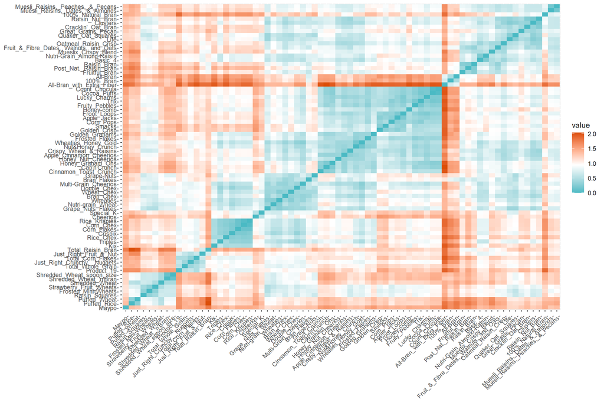

```r
# Correlation chart avoiding the dummified variables
library(factoextra)
distance <- get_dist(cereals_data[,2:13])
fviz_dist(distance, gradient = list(low= "#00AFBB", mid = "white", high = "#DC4E07"))
```

### Determining Optimal Clusters

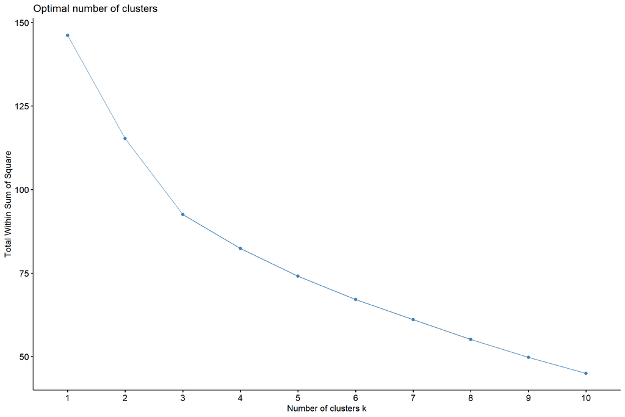

```r
fviz_nbclust(cereals_data, FUN = hcut, method = "wss")
```

- From these estimators, lets assume the optimum K would be 3 We shall evaluate its stability later.

## Hierarchical Clustering

### I will use the euclidean distance measure distance.

```r
dist <- dist(cereals_data[,1:12], method="euclidean")
```

- hierarchical clustering using ward linkage method.

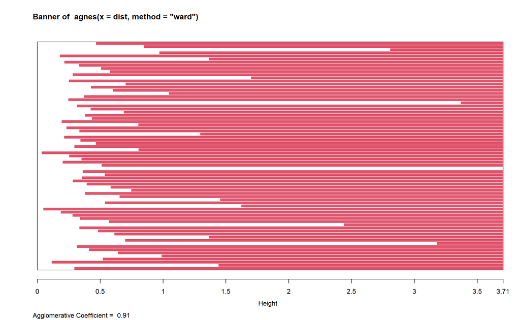

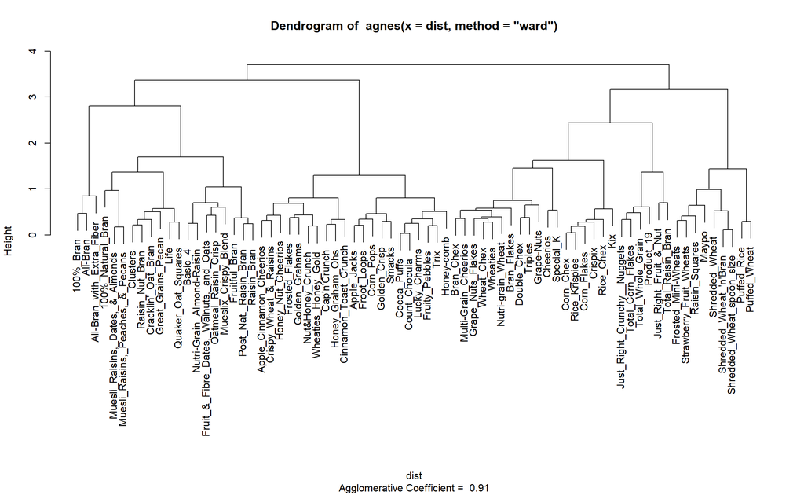

```r
library(cluster)
hc_fit_wd <- agnes(dist, method="ward")
plot(hc_fit_wd)
```

- hierarchical clustering using single linkage method.

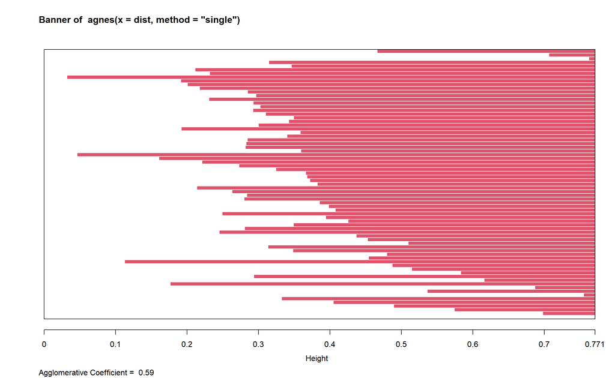

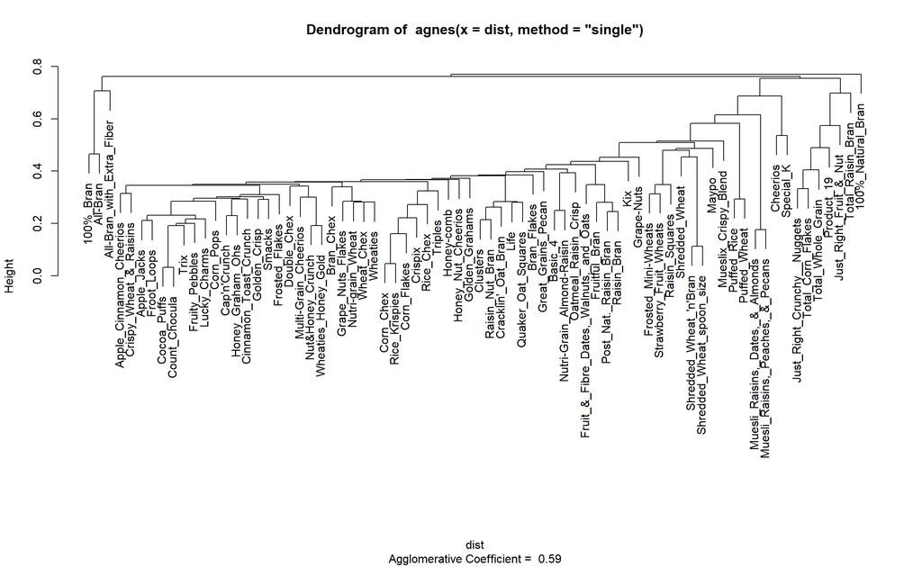

```r
hc_fit_sg <- agnes(dist, method="single")
plot(hc_fit_sg)
```

- hierarchical clustering using complete linkage method.

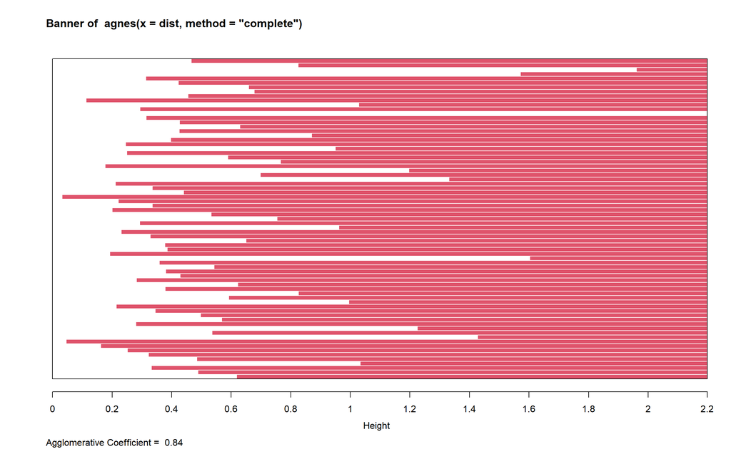

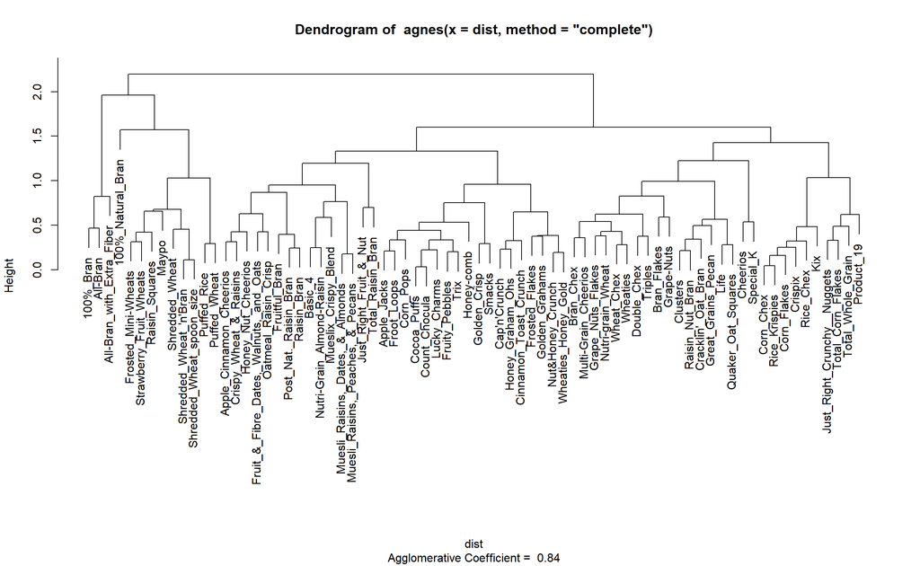

```r
hc_fit_cmp <- agnes(dist, method="complete")
plot(hc_fit_cmp)
```

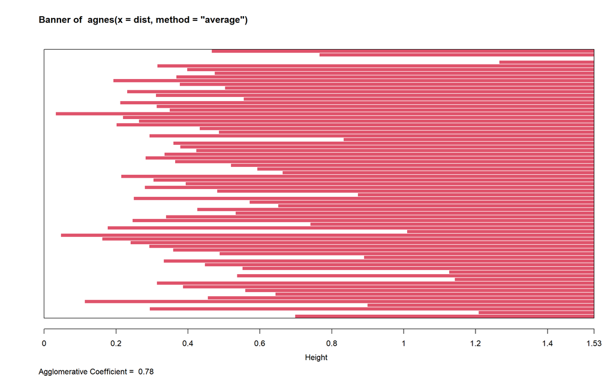

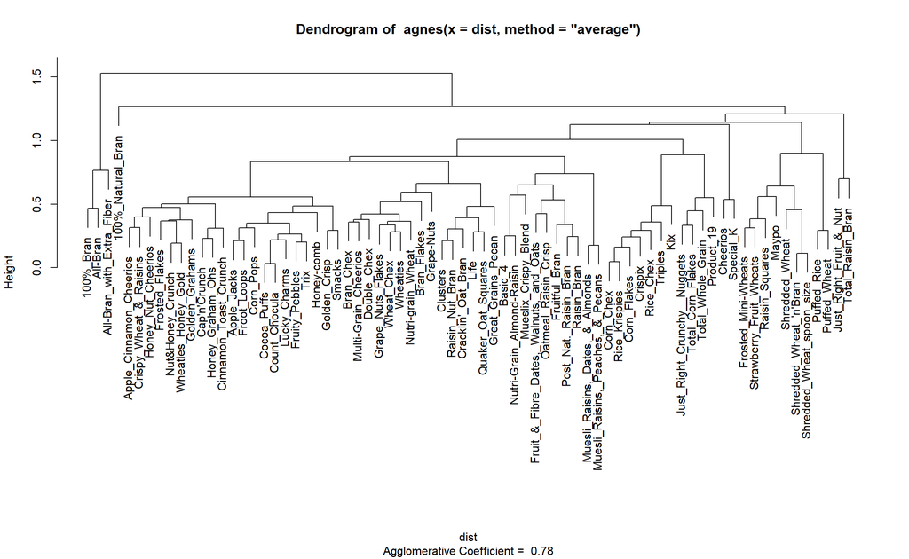

```r
hc_fit_avg <- agnes(dist, method="average")
plot(hc_fit_avg)
```

#### Based on the agglomerative coefficients, “WARD” is the most efficient method to proceed further.

```r
points_hc <- cutree(hc_fit_wd, k=3)
cereals_clusts_hc <- cbind(points_hc, cereals_data)

colnames(cereals_clusts_hc)[1] <- "cluster_hc"
head(cereals_clusts_hc)
```

|  | cluster_hc | calories | protein | fat | sodium | fiber | carbo | sugars | potass | vitamins | weight | cups | rating | mfr_A | mfr_G | mfr_K | mfr_N | mfr_P | mfr_Q | mfr_R | type_C | type_H | shelf_1 | shelf_2 | shelf_3 |
| --- | --- | --- | --- | --- | --- | --- | --- | --- | --- | --- | --- | --- | --- | --- | --- | --- | --- | --- | --- | --- | --- | --- | --- | --- | --- |
| 100%_Bran | 1 | -0.33660934 | 0.2972973 | 0.0 | -0.1011402 | 0.55888031 | -0.5405405 | -0.07387387 | 0.57614758 | -0.04054054 | -0.03081081 | -0.3932973 | 0.3440454 | -0.01351351 | -0.2972973 | -0.3108108 | 0.93243243 | -0.1216216 | -0.09459459 | -0.09459459 | 0.01351351 | -0.01351351 | -0.2567568 | -0.2702703 | 0.527027 |
| 100%_Natural_Bran | 1 | 0.11793612 | 0.0972973 | 0.8 | -0.4605152 | -0.01254826 | -0.3738739 | 0.05945946 | 0.11583012 | -0.29054054 | -0.03081081 | 0.1427027 | -0.1108628 | -0.01351351 | -0.2972973 | -0.3108108 | -0.06756757 | -0.1216216 | 0.90540541 | -0.09459459 | 0.01351351 | -0.01351351 | -0.2567568 | -0.2702703 | 0.527027 |
| All-Bran | 1 | -0.33660934 | 0.2972973 | 0.0 | 0.3051098 | 0.48745174 | -0.4294294 | -0.14054054 | 0.70313170 | -0.04054054 | -0.03081081 | -0.3932973 | 0.2253933 | -0.01351351 | -0.2972973 | 0.6891892 | -0.06756757 | -0.1216216 | -0.09459459 | -0.09459459 | 0.01351351 | -0.01351351 | -0.2567568 | -0.2702703 | 0.527027 |
| All-Bran_with_Extra_Fiber | 1 | -0.51842752 | 0.2972973 | -0.2 | -0.0698902 | 0.84459459 | -0.3738739 | -0.47387387 | 0.73487773 | -0.04054054 | -0.03081081 | -0.2572973 | 0.6784526 | -0.01351351 | -0.2972973 | 0.6891892 | -0.06756757 | -0.1216216 | -0.09459459 | -0.09459459 | 0.01351351 | -0.01351351 | -0.2567568 | -0.2702703 | 0.527027 |
| Apple_Cinnamon_Cheerios | 2 | 0.02702703 | -0.1027027 | 0.2 | 0.0551098 | -0.04826255 | -0.2349850 | 0.19279279 | -0.09051909 | -0.04054054 | -0.03081081 | -0.0572973 | -0.1699960 | -0.01351351 | 0.7027027 | -0.3108108 | -0.06756757 | -0.1216216 | -0.09459459 | -0.09459459 | 0.01351351 | -0.01351351 | 0.7432432 | -0.2702703 | -0.472973 |
| Apple_Jacks | 2 | 0.02702703 | -0.1027027 | -0.2 | -0.1167652 | -0.08397683 | -0.2072072 | 0.45945946 | -0.21750322 | -0.04054054 | -0.03081081 | 0.1427027 | -0.1215628 | -0.01351351 | -0.2972973 | 0.6891892 | -0.06756757 | -0.1216216 | -0.09459459 | -0.09459459 | 0.01351351 | -0.01351351 | -0.2567568 | 0.7297297 | -0.472973 |

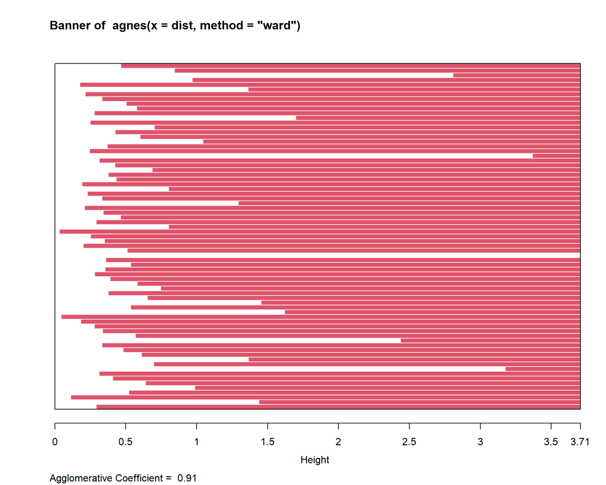

```r
library(cluster)
plot(hc_fit_wd)
```

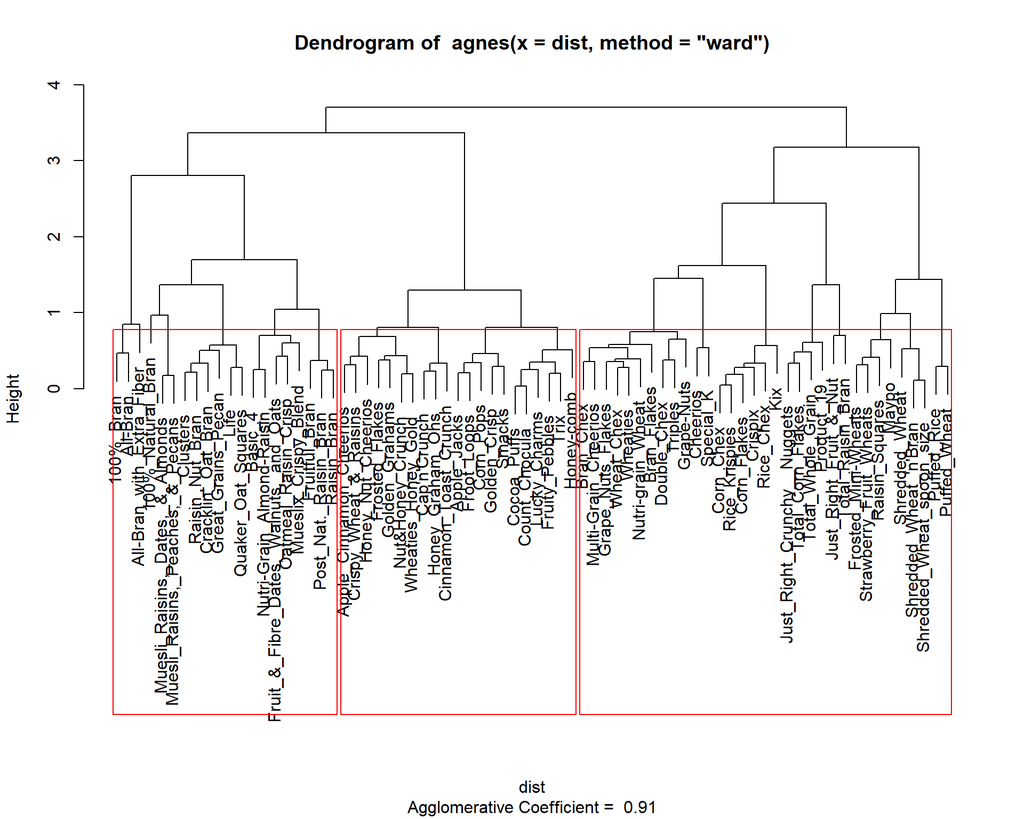

```r
rect.hclust(hc_fit_wd, k = 3, border = "red")
```

### Checking Quality of clusters Created

```
- The silhouette width/value is a measure of how similar an object is to its own cluster (cohesion) compared to other clusters (separation)  [i.e., intra-cluster cohesion and inter-cluster separation]
- Ranges from -1 to +1
- Values closer to 1 means higher quality of the cluster created
```

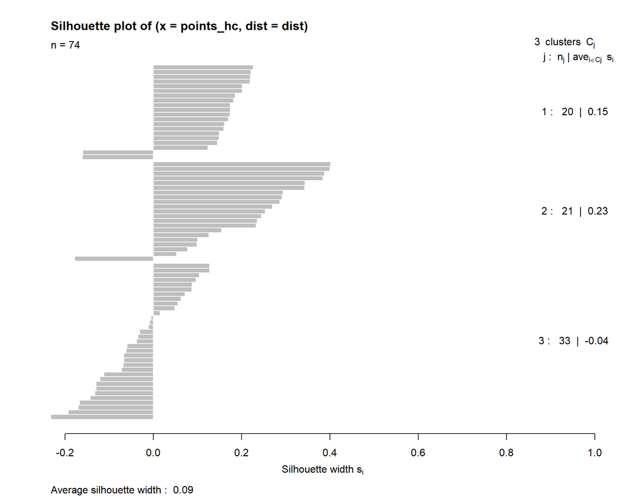

```r
library(cluster)
dist = daisy(x = cereals_data, metric = "euclidean")
sil_value = silhouette(points_hc, dist = dist)
plot(sil_value)
```

- finding the optimal number of clusters where silhouette width would be maximum

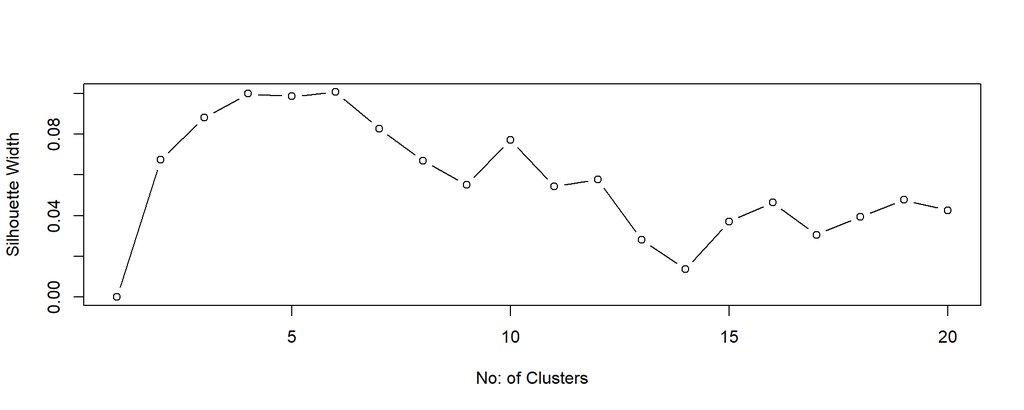

```r
sil_value_hc = 0
for (i in 2:20) {
  points_hc <- cutree(hc_fit_wd, k = i)
  sil_value_hc[i] = mean(silhouette(points_hc, dist = dist)[,3])
}
plot(1:20, sil_value_hc, type = "b", xlab = "No: of Clusters", ylab = "Silhouette Width")
```

- According to the Silhoutte, the optimized cluster value is 4 and 6. Lets check the stability of both 4 and 6 clusters with clusterboot method now.

### Cluster Stability

#### Checking for Stability of k=4.

- clusterboot is an integrated function that computes the clustering as well, using interface functions for various clustering methods implemented in R (several interface functions are provided, but you can implement further ones for your favourite clustering method)
- Clusterboot function using library(fpc)

```r
library(fpc)
#Input the scaled cereals_data
hclust_stability = clusterboot(cereals_data, clustermethod=hclustCBI, method="ward.D2", k=4, count = FALSE)
```

- What are the cluster stability values? Values > 0.85 denote very stable clusters. 0.6 - 0.75 means the clusters show some patterns but needs to be investigated further

```r
#Cluster stability values
hclust_stability$bootmean
```

```
## [1] 0.6541825 0.6004057 0.6193093 0.6900000
```

- How many times the different clusters were dissolved

```r
#Cluster dissolution rate. If maximum Jaccard coefficient < 0.5, that cluster is assumed to be dissolved. Below code shows the number of times each cluster was dissolved. The lower the value, the better.
hclust_stability$bootbrd
```

```
## [1] 35 41 36 31
```

#### Checking for Stability of k=6.

```r
hclust_stability = clusterboot(cereals_data, clustermethod=hclustCBI, method="ward.D2", k=6, count = FALSE)
```

- What are the cluster stability values? Values > 0.85 denote very stable clusters. 0.6 - 0.75 means the clusters show some patterns but needs to be investigated further

```r
#Cluster stability values
hclust_stability$bootmean
```

```
## [1] 0.6783651 0.4780906 0.6388820 0.7087018 0.6867587 0.5800000
```

- How many times the different clusters were dissolved

```r
#Cluster dissolution rate. If maximum Jaccard coefficient < 0.5, that cluster is assumed to be dissolved. Below code shows the number of times each cluster was dissolved. The lower the value, the better.
hclust_stability$bootbrd
```

```
## [1] 31 71 24 11 19 42
```

#### Hence, after checking the stability of both posible values of K; the best choice is 4.

- Implementing the the hierarchical clustering with k=4

```r
points_hc_4 <- cutree(hc_fit_wd, k=4)
cereals_clusts_hc_4 <- cbind(points_hc_4, cereals_data)

colnames(cereals_clusts_hc_4)[1] <- "cluster_hc"
head(cereals_clusts_hc_4)
```

|  | cluster_hc | calories | protein | fat | sodium | fiber | carbo | sugars | potass | vitamins | weight | cups | rating | mfr_A | mfr_G | mfr_K | mfr_N | mfr_P | mfr_Q | mfr_R | type_C | type_H | shelf_1 | shelf_2 | shelf_3 |
| --- | --- | --- | --- | --- | --- | --- | --- | --- | --- | --- | --- | --- | --- | --- | --- | --- | --- | --- | --- | --- | --- | --- | --- | --- | --- |
| 100%_Bran | 1 | -0.33660934 | 0.2972973 | 0.0 | -0.1011402 | 0.55888031 | -0.5405405 | -0.07387387 | 0.57614758 | -0.04054054 | -0.03081081 | -0.3932973 | 0.3440454 | -0.01351351 | -0.2972973 | -0.3108108 | 0.93243243 | -0.1216216 | -0.09459459 | -0.09459459 | 0.01351351 | -0.01351351 | -0.2567568 | -0.2702703 | 0.527027 |
| 100%_Natural_Bran | 1 | 0.11793612 | 0.0972973 | 0.8 | -0.4605152 | -0.01254826 | -0.3738739 | 0.05945946 | 0.11583012 | -0.29054054 | -0.03081081 | 0.1427027 | -0.1108628 | -0.01351351 | -0.2972973 | -0.3108108 | -0.06756757 | -0.1216216 | 0.90540541 | -0.09459459 | 0.01351351 | -0.01351351 | -0.2567568 | -0.2702703 | 0.527027 |
| All-Bran | 1 | -0.33660934 | 0.2972973 | 0.0 | 0.3051098 | 0.48745174 | -0.4294294 | -0.14054054 | 0.70313170 | -0.04054054 | -0.03081081 | -0.3932973 | 0.2253933 | -0.01351351 | -0.2972973 | 0.6891892 | -0.06756757 | -0.1216216 | -0.09459459 | -0.09459459 | 0.01351351 | -0.01351351 | -0.2567568 | -0.2702703 | 0.527027 |
| All-Bran_with_Extra_Fiber | 1 | -0.51842752 | 0.2972973 | -0.2 | -0.0698902 | 0.84459459 | -0.3738739 | -0.47387387 | 0.73487773 | -0.04054054 | -0.03081081 | -0.2572973 | 0.6784526 | -0.01351351 | -0.2972973 | 0.6891892 | -0.06756757 | -0.1216216 | -0.09459459 | -0.09459459 | 0.01351351 | -0.01351351 | -0.2567568 | -0.2702703 | 0.527027 |
| Apple_Cinnamon_Cheerios | 2 | 0.02702703 | -0.1027027 | 0.2 | 0.0551098 | -0.04826255 | -0.2349850 | 0.19279279 | -0.09051909 | -0.04054054 | -0.03081081 | -0.0572973 | -0.1699960 | -0.01351351 | 0.7027027 | -0.3108108 | -0.06756757 | -0.1216216 | -0.09459459 | -0.09459459 | 0.01351351 | -0.01351351 | 0.7432432 | -0.2702703 | -0.472973 |
| Apple_Jacks | 2 | 0.02702703 | -0.1027027 | -0.2 | -0.1167652 | -0.08397683 | -0.2072072 | 0.45945946 | -0.21750322 | -0.04054054 | -0.03081081 | 0.1427027 | -0.1215628 | -0.01351351 | -0.2972973 | 0.6891892 | -0.06756757 | -0.1216216 | -0.09459459 | -0.09459459 | 0.01351351 | -0.01351351 | -0.2567568 | 0.7297297 | -0.472973 |

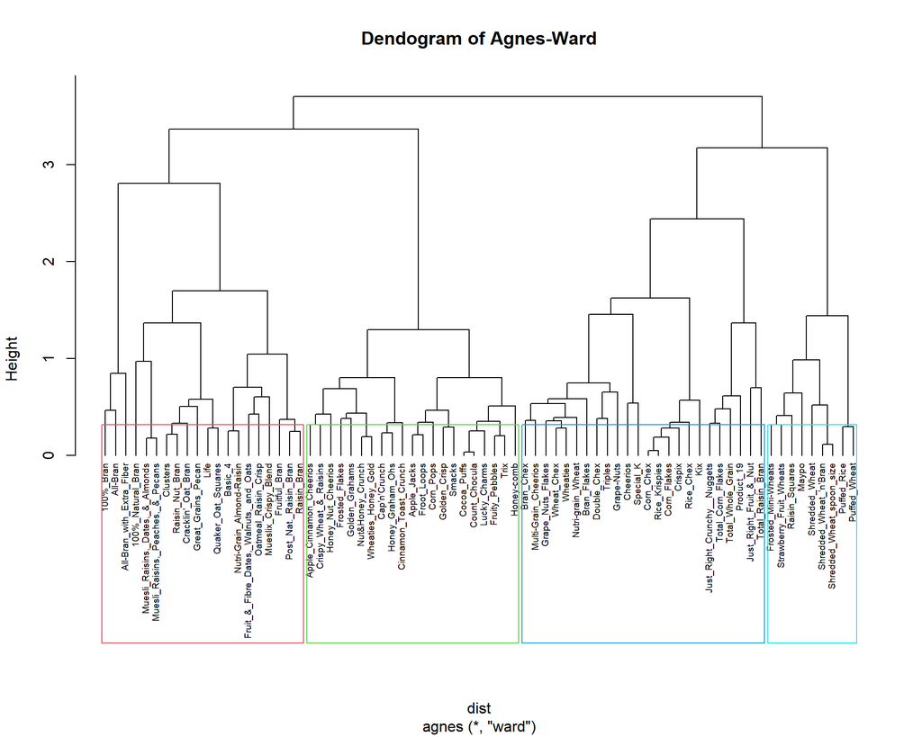

```r
pltree(hc_fit_wd, cex = 0.6, hang = -1, main = "Dendogram of Agnes-Ward")
rect.hclust(hc_fit_wd, k = 4, border = 2:5)
```

#### checking Quality of clusters Created

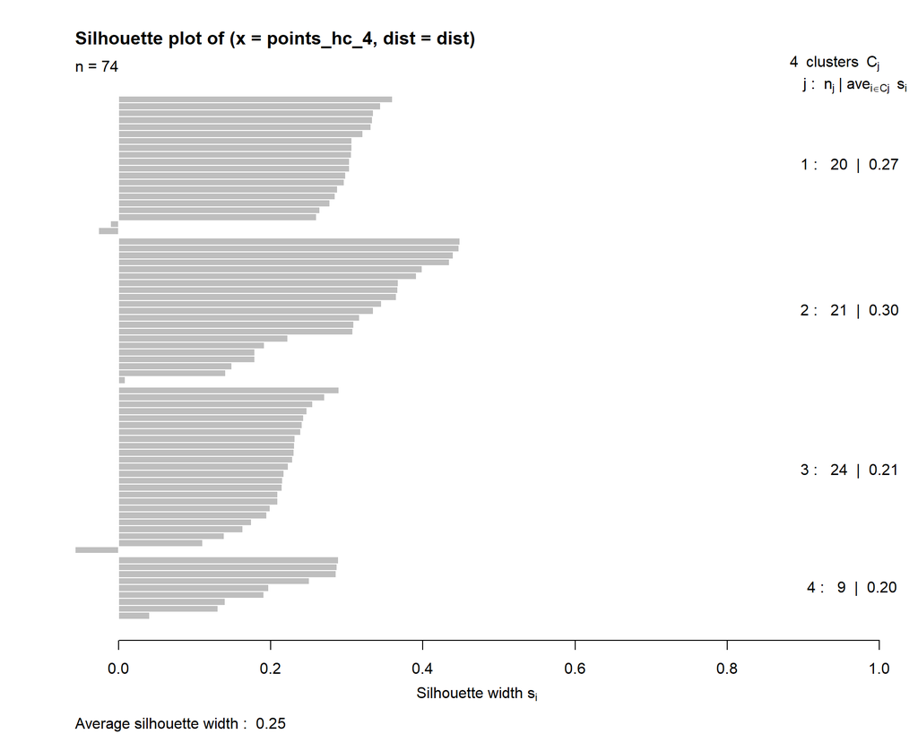

```r
library(cluster)
dist = daisy(x = cereals_clusts_hc_4, metric = "euclidean")
sil_value = silhouette(points_hc_4, dist = dist)
plot(sil_value)
```

##### Selection of the cluster that would be the best cereal for breakfast are based on:

```
- Sodium and Sugar content should be minimal
```

```r
library(hrbrthemes)
library(GGally)
```

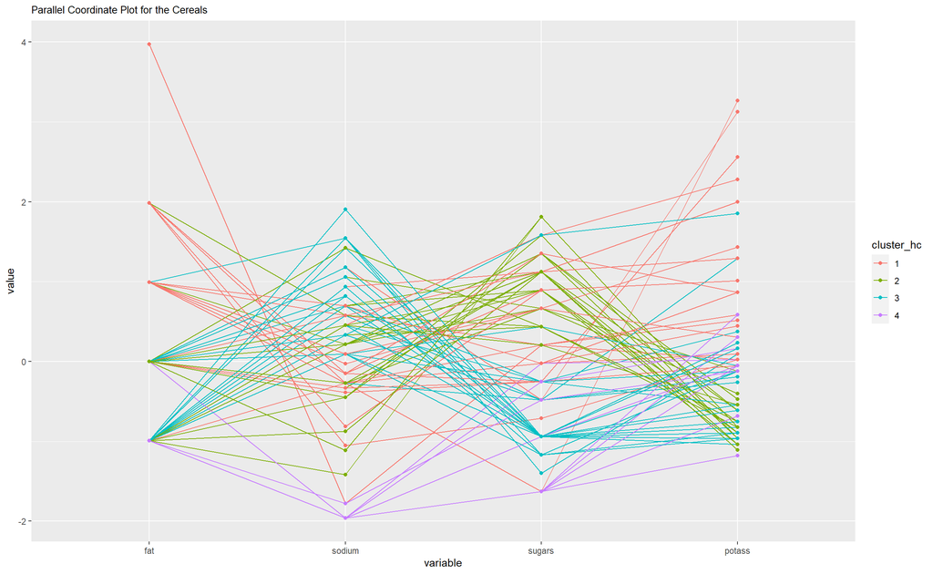

```r
cereals_clusts_hc_4$cluster_hc <- as.factor(cereals_clusts_hc_4$cluster_hc)

ggparcoord(cereals_clusts_hc_4,
    columns = c(4,5,8,9), groupColumn = 1,
    showPoints = TRUE,
    title = "Parallel Coordinate Plot for the Cereals",
    alphaLines = 1
    ) + theme(plot.title = element_text(size=10))
```

- Approaching forward with an elimination technique, we will cancel a few parameters to be considered while choosing the best cluster for healthy breakfast.
  - We will consider fat, sodium, sugars and potash for choosing; the cereal having the least nutrition value in these criteria should be eliminated from selection.
  - Cluster 4 seems to be the best choice.